# Prediction Assignment Writeup

elkemat

After importing the data from the csv file and some basic exploration of the variables I split the data in training and testing data with random subsampling.

```r
library(ggplot2)
library(caret)

training.data <- read.csv(file = "pml-training.csv")
testing.data <- read.csv(file = "pml-testing.csv")

inTrain <- createDataPartition(y = training.data$classe, p = 0.75, list = FALSE)
training <- training.data[inTrain, ]
testing <- training.data[-inTrain, ]

names(training)
str(training)
```

For the data six young health participants were asked to perform one set of 10 repetitions of the Unilateral Dumbbell Biceps Curl in five different fashions:

- exactly according to the specification (Class A),
- throwing the elbows to the front (Class B),
- lifting the dumbbell only halfway (Class C),
- lowering the dumbbell only halfway (Class D) and
- throwing the hips to the front (Class E).

After exploring the data, I decided on using the acceleration data of the four sensors (belt, arm, forearm and dumbbell) as they potentially vary between the classes A to E. I created a new data frame only including these variables and the classe.

```r
training.predictors <- with(training, data.frame(classe,
                                          #belt sensor
                                          total_accel_belt, accel_belt_x,
                                          accel_belt_y, accel_belt_z,
                                          # arm sensor
                                          total_accel_arm, accel_arm_x,
                                          accel_arm_y, accel_arm_z,
                                          # dumbbell sensor
                                          total_accel_dumbbell, accel_dumbbell_x,
                                          accel_dumbbell_y, accel_dumbbell_z,
                                          # forearm sensor
                                          total_accel_forearm, accel_forearm_x,
                                          accel_forearm_y, accel_forearm_z))
str(training.predictors)
```

```
## 'data.frame':    14718 obs. of  17 variables:
##  $ classe              : Factor w/ 5 levels "A","B","C","D",..: 1 1 1 1 1 1 1 1 1 1 ...
##  $ total_accel_belt    : int  3 3 3 3 3 3 3 3 3 3 ...
##  $ accel_belt_x        : int  -21 -22 -20 -21 -21 -22 -22 -21 -21 -22 ...
##  $ accel_belt_y        : int  4 4 5 2 4 3 4 4 2 2 ...
##  $ accel_belt_z        : int  22 22 23 24 21 21 21 22 23 23 ...
##  $ total_accel_arm     : int  34 34 34 34 34 34 34 34 34 34 ...
##  $ accel_arm_x         : int  -288 -290 -289 -289 -289 -289 -289 -288 -290 -288 ...
##  $ accel_arm_y         : int  109 110 110 111 111 111 111 110 110 111 ...
##  $ accel_arm_z         : int  -123 -125 -126 -123 -122 -125 -124 -124 -123 -123 ...
##  $ total_accel_dumbbell: int  37 37 37 37 37 37 37 37 37 37 ...
##  $ accel_dumbbell_x    : int  -234 -233 -232 -233 -234 -232 -234 -235 -233 -233 ...
##  $ accel_dumbbell_y    : int  47 47 46 48 48 47 46 48 47 47 ...
##  $ accel_dumbbell_z    : int  -271 -269 -270 -270 -269 -270 -272 -270 -269 -270 ...
##  $ total_accel_forearm : int  36 36 36 36 36 36 36 36 36 36 ...
##  $ accel_forearm_x     : int  192 192 196 189 193 195 193 190 193 191 ...
##  $ accel_forearm_y     : int  203 203 204 206 203 205 205 205 205 203 ...
##  $ accel_forearm_z     : int  -215 -216 -213 -214 -215 -215 -213 -215 -214 -215 ...
```

I then used “Spot Check Algorithms” (Reference: https://machinelearningmastery.com/evaluate-machine-learning-algorithms-with-r/) to compare the accuracy of different algorithms. I set up the conditions to assure comparability between the different algorithms (with set.seed etc.). I used a 10-fold cross validation to get a better estimate of the accuracy with the training set.

```r
control <- trainControl(method = "repeatedcv", number = 10, repeats = 1)
seed <- 1234
metric <- "Accuracy"
```

The “Spot Check Algorithms” shows that fitting a random forest has the highest accuracy.

```r
# Linear Methods: Linear Discriminant Analysis
set.seed(seed)
fit.lda <- train(classe ~ ., data = training.predictors, method = "lda",
                 metric = metric, trControl = control)

# Linear Methods: multinomial regression model
set.seed(seed)
fit.glmnet <- train(classe ~ ., data = training.predictors, method = "glmnet",
                 metric = metric, trControl = control)

# Non-Linear Methots: Naive Bayes
set.seed(seed)
fit.nb <- train(classe ~ ., data = training.predictors, method = "nb",
                 metric = metric, trControl = control)

# Non-Linear Methots:kNN
set.seed(seed)
fit.knn <- train(classe ~ ., data = training.predictors, method = "knn",
                metric = metric, trControl = control)

# Trees and Rules: CART
set.seed(seed)
fit.cart <- train(classe ~ ., data = training.predictors, method = "rpart",
                metric = metric, trControl = control)

# Ensembles of Trees: Bagged CART
set.seed(seed)
fit.treebag<- train(classe ~ ., data = training.predictors, method = "treebag",
                metric = metric, trControl = control)

# Ensembles of Trees: Random Forest
set.seed(seed)
fit.rf <- train(classe ~ ., data = training.predictors, method = "rf",
                metric = metric, trControl = control)

# Ensembles of Trees: Stochastic Gradient Boosting (Generalized Boosted Modeling)
set.seed(seed)
fit.gbm <- train(classe ~ ., data = training.predictors, method = "gbm",
                metric = metric, trControl = control, verbose = FALSE)

# resamples function in caret collates the resampling results from the models
results <- resamples(list(lda = fit.lda, glmnet = fit.glmnet, nb = fit.nb,
                          knn = fit.knn, cart = fit.cart, treebag = fit.treebag,
                          rf = fit.rf, gbm = fit.gbm))

# Comparison of algorithms
summary(results)
```

```
##
## Call:
## summary.resamples(object = results)
##
## Models: lda, glmnet, nb, knn, cart, treebag, rf, gbm
## Number of resamples: 10
##
## Accuracy
##           Min. 1st Qu. Median   Mean 3rd Qu.   Max. NA's
## lda     0.4813  0.5035 0.5127 0.5090  0.5158 0.5241    0
## glmnet  0.4942  0.5116 0.5246 0.5202  0.5306 0.5323    0
## nb      0.5370  0.5470 0.5556 0.5578  0.5661 0.5860    0
## knn     0.8398  0.8517 0.8556 0.8562  0.8643 0.8696    0
## cart    0.3834  0.3982 0.4236 0.4176  0.4308 0.4592    0
## treebag 0.8995  0.9059 0.9113 0.9117  0.9153 0.9273    0
## rf      0.9388  0.9404 0.9449 0.9456  0.9484 0.9552    0
## gbm     0.8151  0.8165 0.8213 0.8235  0.8265 0.8390    0
##
## Kappa
##           Min. 1st Qu. Median   Mean 3rd Qu.   Max. NA's
## lda     0.3359  0.3636 0.3745 0.3706  0.3802 0.3911    0
## glmnet  0.3527  0.3756 0.3917 0.3858  0.3986 0.4028    0
## nb      0.4152  0.4271 0.4378 0.4405  0.4513 0.4759    0
## knn     0.7971  0.8121 0.8173 0.8179  0.8282 0.8351    0
## cart    0.1893  0.2121 0.2460 0.2376  0.2543 0.2977    0
## treebag 0.8727  0.8812 0.8877 0.8883  0.8928 0.9080    0
## rf      0.9226  0.9246 0.9303 0.9312  0.9347 0.9433    0
## gbm     0.7651  0.7674 0.7734 0.7763  0.7803 0.7962    0
```

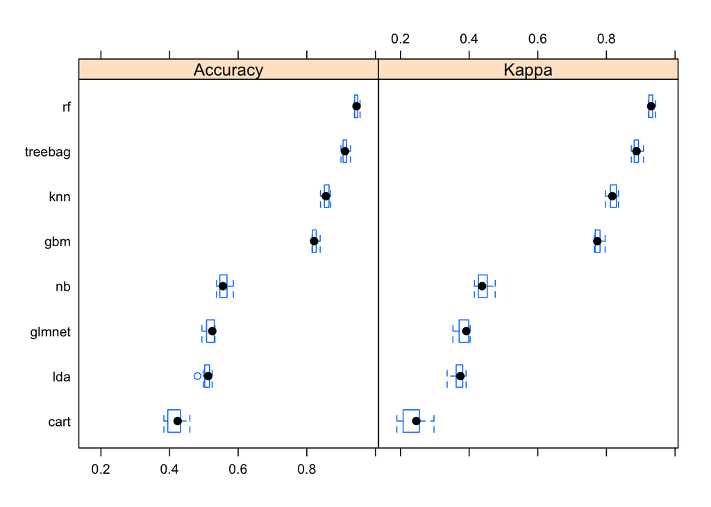

```r
bwplot(results)
```

To avoid overfitting the model, I then tried to model only with the most important variables given bei varImp() and compared it with the original model.

```r
varImp(fit.rf)
```

```
## rf variable importance
##
##                      Overall
## accel_belt_z         100.000
## accel_dumbbell_y      94.675
## accel_dumbbell_z      87.349
## accel_forearm_x       64.767
## accel_arm_x           62.101
## accel_dumbbell_x      59.604
## accel_forearm_z       46.828
## accel_arm_y           36.145
## total_accel_dumbbell  28.551
## accel_arm_z           27.918
## accel_forearm_y       25.297
## total_accel_belt      16.607
## accel_belt_x          14.015
## accel_belt_y           7.924
## total_accel_forearm    3.025
## total_accel_arm        0.000
```

```r
set.seed(seed)
fit.rf.red <- train(classe ~ accel_dumbbell_y + accel_belt_z + accel_dumbbell_z
                    + accel_forearm_x + accel_dumbbell_x + accel_arm_x,
                    data = training.predictors, method = "rf",
                    metric = metric, trControl = control)
results2 <- resamples(list(rf = fit.rf, rf.red = fit.rf.red))
summary(results2)
```

```
##
## Call:
## summary.resamples(object = results2)
##
## Models: rf, rf.red
## Number of resamples: 10
##
## Accuracy
##          Min. 1st Qu. Median   Mean 3rd Qu.   Max. NA's
## rf     0.9388  0.9404 0.9449 0.9456  0.9484 0.9552    0
## rf.red 0.8729  0.8776 0.8849 0.8852  0.8917 0.8980    0
##
## Kappa
##          Min. 1st Qu. Median   Mean 3rd Qu.   Max. NA's
## rf     0.9226  0.9246 0.9303 0.9312  0.9347 0.9433    0
## rf.red 0.8389  0.8449 0.8544 0.8547  0.8629 0.8710    0
```

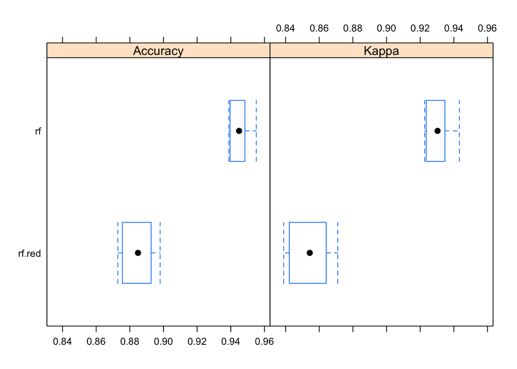

```r
bwplot(results2)
```

As the model with six predictors compared to 16 predictors only drops accuracy of about 5% (from 94 to 89), I chose this model for the final validation.

```r
fit.rf.pred.red.out <- predict(fit.rf.red, newdata = testing)
confusionMatrix(fit.rf.pred.red.out, testing$classe)
```

```
## Confusion Matrix and Statistics
##
##           Reference
## Prediction    A    B    C    D    E
##          A 1306   54   34   36   22
##          B   16  803   35    8   27
##          C   38   66  766   47   25
##          D   34   15   14  704   18
##          E    1   11    6    9  809
##
## Overall Statistics
##
##                Accuracy : 0.8948
##                  95% CI : (0.8859, 0.9032)
##     No Information Rate : 0.2845
##     P-Value [Acc > NIR] : < 2.2e-16
##
##                   Kappa : 0.8667
##  Mcnemar's Test P-Value : 3.452e-15
##
## Statistics by Class:
##
##                      Class: A Class: B Class: C Class: D Class: E
## Sensitivity            0.9362   0.8462   0.8959   0.8756   0.8979
## Specificity            0.9584   0.9783   0.9565   0.9802   0.9933
## Pos Pred Value         0.8994   0.9033   0.8132   0.8968   0.9677
## Neg Pred Value         0.9742   0.9636   0.9775   0.9757   0.9774
## Prevalence             0.2845   0.1935   0.1743   0.1639   0.1837
## Detection Rate         0.2663   0.1637   0.1562   0.1436   0.1650
## Detection Prevalence   0.2961   0.1813   0.1921   0.1601   0.1705
## Balanced Accuracy      0.9473   0.9122   0.9262   0.9279   0.9456
```

Applying the chosen model to the testing data set I separated at the beginning, I assume the out of sample error to be 11% (1-Accuracy).